# Dataiku Test Report

# 1. Overview

This is a project from Dataiku. The main purpose of this project is to predict whether people save more or less than $50,000 / year. Some census infomation is give (see the “data” folder), such as age, class of worker, industry and so on.

This document is orgenized as follows:

- First, a general explore of the train data set, such as dimension, head, response variables and missing values, is presented.
- Second, Exploratory Data Analysis is conducted.
- Third, different machine learning models are applied and evaluated.
- Forth, the final prediction results are presented.
- Fifth, the problem and future improvements are discussed.

# 2. Dataset overview

```r
##### Read Data #####
setwd("~/Documents/JOB!!/Interview/Dataiku/us_census_full")
train.data= read.csv("census_income_learn.csv")
data.colname=c("age", "class.of.worker", "industry.code", "occupation.code", "education", "wage.per.hour",
               "enrolled.in.edu.inst.last.wk", "marital.status", "major.industry.code", "major.occupation.code",
               "race", "hispanic.Origin", "sex", "member.of.a.labor.union", "reason.for.unemployment",
               "full.or.part.time.employment.stat", "capital.gains", "capital.losses",
               "federal.income.tax.liability", "tax.filer.status", "region.of.previous.residence",
               "state.of.previous.residence", "detailed.household.and.family.stat",
               "detailed.household.summary.in.household", "instance.weight", "migration.code.change.in.msa",
               "migration.code.change.in.reg", "migration.code.move.within.reg", "live.in.this.house.1.year.ago",
               "migration.prev.res.in.sunbelt","num.persons.worked.for.employer", "total.person.earnings",
               "country.of.birth.father","country.of.birth.mother", "country.of.birth.self", "citizenship",
               "own.business.or.self.employed", "fill.inc.questionnaire.for.veterans.admin", "veterans.benefits",
               "weeks.worked.in.year", "year", "saving")#.Add.col.names
colnames(train.data)= data.colname
# Read package
library(ggplot2)
library(memisc)
library(randomForest)
library(ada)
library(glmnet)
# Explore the dataset
dim(train.data)
```

```
## [1] 199522     42
```

```r
head(train.data)
```

```
##   age                 class.of.worker industry.code occupation.code
## 1  58  Self-employed-not incorporated             4              34
## 2  18                 Not in universe             0               0
## 3   9                 Not in universe             0               0
## 4  10                 Not in universe             0               0
## 5  48                         Private            40              10
## 6  42                         Private            34               3
##                     education wage.per.hour enrolled.in.edu.inst.last.wk
## 1  Some college but no degree             0              Not in universe
## 2                  10th grade             0                  High school
## 3                    Children             0              Not in universe
## 4                    Children             0              Not in universe
## 5  Some college but no degree          1200              Not in universe
## 6  Bachelors degree(BA AB BS)             0              Not in universe
##                     marital.status                major.industry.code
```

[output cut: 104 more lines]

```r
summary(train.data$saving)
```

```
##  - 50000.   50000+.
##    187140     12382
```

The dataset is imbalanced. So we should not only look at the overall prediction accuracy, but also the accuracy for each side.

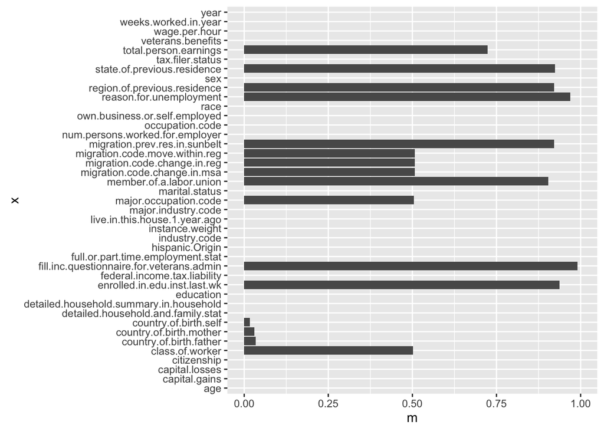

```r
missing_value= apply(train.data, 2, function(x) sum(x == " ?" | x == " Not in universe"))
miss_percentage= data.frame(x= data.colname[1:41], m=missing_value[1:41]/199522)
ggplot(data=miss_percentage,aes(x=x,y=m)) + geom_bar(stat="identity")+coord_flip() + ylim(0,1)
```

Here, we regard “?” and “Not in universe” as missing value. As we can see, there are a lot of missing values in some columns, some of which are almost zero, eg. “own business or self employed”. However, the data was treated as a level of factors, we do not need to further manipulate them.

# 2. EDA

We further explore some variable distributions and extreme values.

### 2.1 Age and marital status

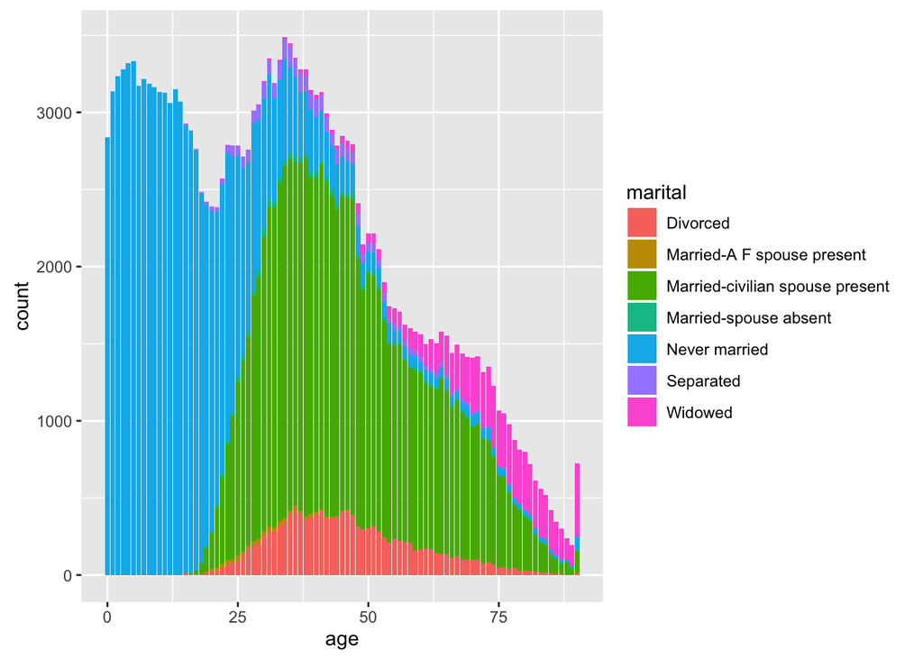

```r
ggplot(data=data.frame(age= train.data$age, marital= train.data$marital),aes(x=age,fill=marital)) + geom_bar()
```

According to this bar plot, the number of people who is 90 years old is extremely high. After checking with the original data, I believe that this should be people who is equal or orlder than 90 years old. From about 20 years old, the married and divorced numbers are increasing. From 50 years old, the widowed number is increasing.

### 2.2 Education

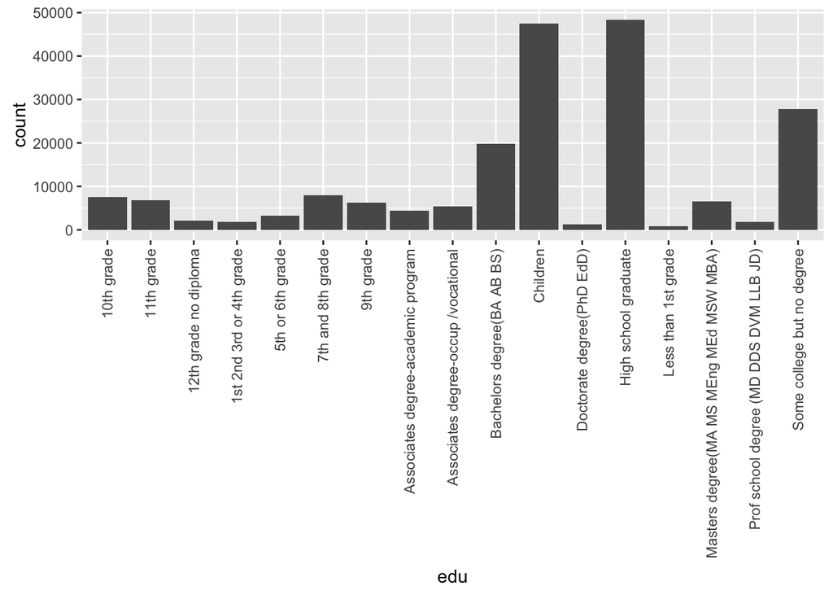

```r
ggplot(data= data.frame(edu=train.data$education),aes(edu))+ geom_bar() + theme(axis.text.x=element_text(angle=90,hjust=1,vjust=0.5))
```

In this chart, we can see that “Children” and “High school graduate” are the most, followed by “Some college but no degree” and “Bechalors degree”. This matches our common sense.

### 2.3 Working status related info

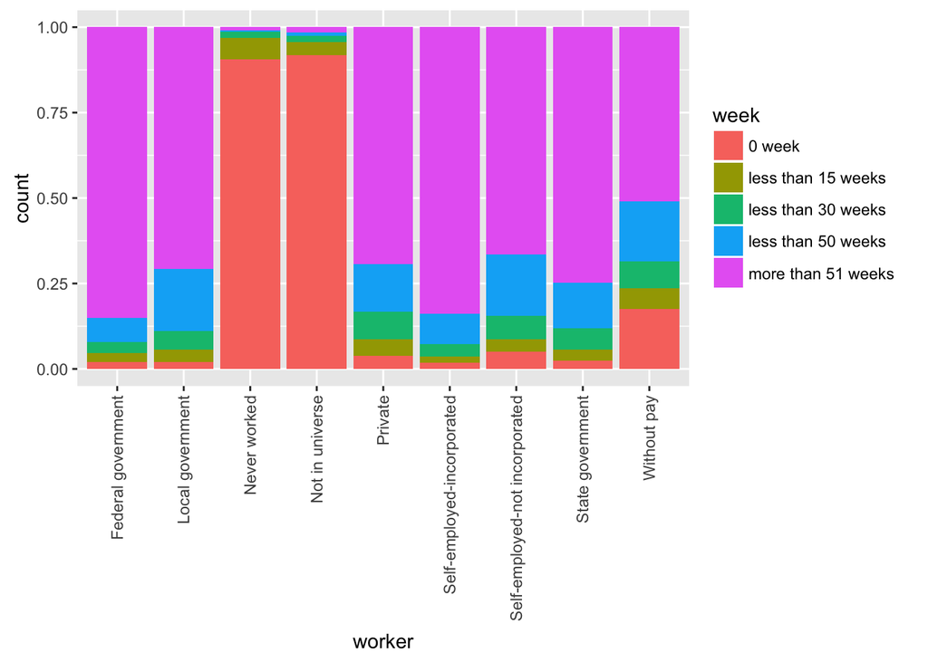

```r
weeks = vector()
weeks[train.data$weeks == 0] = "0 week"
weeks[train.data$weeks <= 15 & train.data$weeks >0]= "less than 15 weeks"
weeks[train.data$weeks <= 30 & train.data$weeks >15] = "less than 30 weeks"
weeks[train.data$weeks <= 50 & train.data$weeks >30]= "less than 50 weeks"
weeks[train.data$weeks >=51] = "more than 51 weeks"
ggplot(data.frame(worker= train.data$class, week= weeks), aes(x = worker, fill = week)) + geom_bar(width = 0.9, position = "fill") +theme(axis.text.x=element_text(angle=90,hjust=1,vjust=0.5))
```

Those who work more than 51 weeks are majority, in most classes of worker.